# Fun Friday: Structural Breaks Part 1

### c. Structural Breaks with More Data Types and Different Segment Sizes

#### I. Exponential curves:

We need to test the breakpoint function’s flexibility to change the minimal segment size either given as a fraction relative to the sample size or as an interger giving the minimal number of observations in each segment.

Generate regular sequences between 0 and 100 by 1 for a vector x. For x2, generate regular sequences between -50 and 50 by 1. Make vector y1 vector x to the fourth power, vector y2 vector x to the one fourth power, and vector y3 vector x2 to the third power.

```r
x<-seq(0,100,by=1)
x2 <- seq(-50,50,by=1)

y1 <- x^4
y2 <- (x)^(1/4)
y3 <- x2^3
```

Let’s look at y1 first. How does changing the resolution, a.k.a. the minimum number of observations required for each breakpoint, affect the estimates of the breakpoints?

```r
f.break <- Fstats(y1~1)
plot(f.break)
```

[figure not shown]

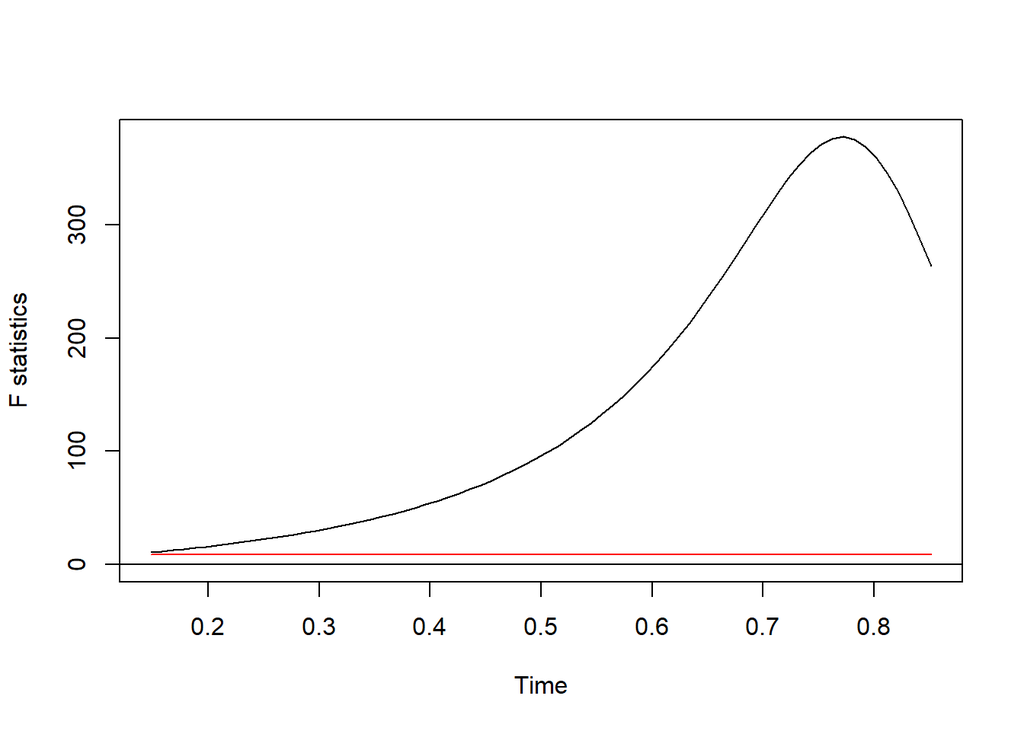

```r
y1a.bp<-breakpoints(y1~1)
y1a.bp
```

```
##
##   Optimal 4-segment partition:
##
## Call:
## breakpoints.formula(formula = y1 ~ 1)
##
## Breakpoints at observation number:
## 55 71 86
##
## Corresponding to breakdates:
## 0.5445545 0.7029703 0.8514851
```

```r
plot(y1)
abline(v=time(y1)[y1a.bp$breakpoints],col=2,lty=2)
```

[figure not shown]

```r
f.break <- Fstats(y1~1,from=5)
plot(f.break)
```

[figure not shown]

[figure not shown]

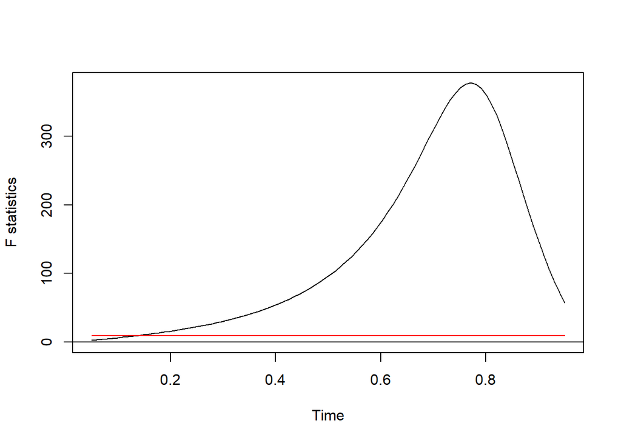

```r
f.break <- Fstats(y1~1,from=5)
plot(f.break)
```

```r
y1b.bp<-breakpoints(y1~1,h=5)
y1b.bp
```

```
##
##   Optimal 11-segment partition:
##
## Call:
## breakpoints.formula(formula = y1 ~ 1, h = 5)
##
## Breakpoints at observation number:
## 40 52 60 66 71 76 81 86 91 96
##
## Corresponding to breakdates:
## 0.3960396 0.5148515 0.5940594 0.6534653 0.7029703 0.7524752 0.8019802 0.8514851 0.9009901 0.950495
```

```r
plot(y1)
abline(v=time(y1)[y1b.bp$breakpoints],col=4,lty=2,lwd=2)
abline(v=time(y1)[y1a.bp$breakpoints],col=2,lty=2)
```

[figure not shown]

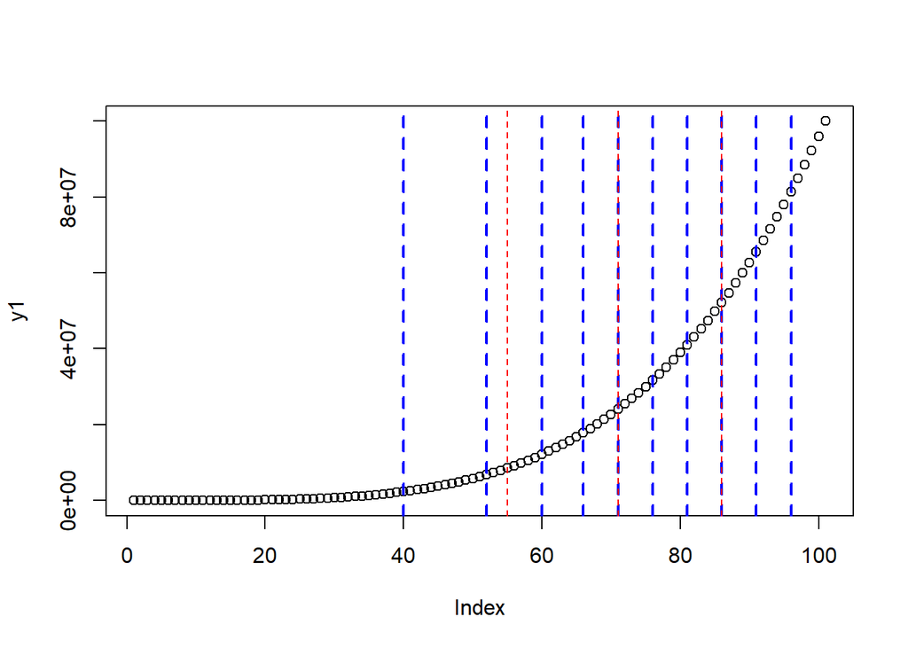

The first `Fstat` and breakpoint location graphs of y1 shows where the breaks occur in the data with the default resolution of `from=0.15` and `h=0.15` respectively (that is, a minimum of 15% of the observations in each area of stability). The second `Fstat` graph and the `breakpoints` function uses `from=5` and `h=5` (a minimum of 5 observations in each area of stability), while the final graph plots the new breakpoints in blue and the old breakpoints in red. As we can see, changing the *from* and *h* values can change the number of breaks while potentially keeping some of the same breakpoints. The values we choose should be based on a) empirical theory that suggests the minimum number of observations before a change can be detected or b) the resolution we decide we want to have.

```r
f.break <- Fstats(y2~1)
plot(f.break)
```

[figure not shown]

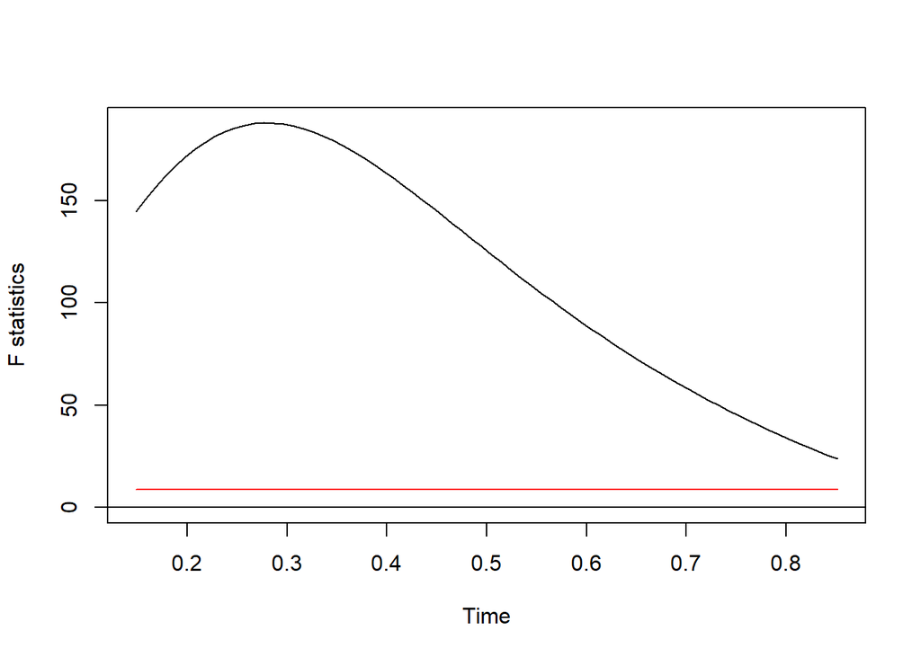

```r
y2.bp<-breakpoints(y2~1,h=5)
y2.bp
```

```
##
##   Optimal 7-segment partition:
##
## Call:
## breakpoints.formula(formula = y2 ~ 1, h = 5)
##
## Breakpoints at observation number:
## 5 12 23 37 55 76
##
## Corresponding to breakdates:
## 0.04950495 0.1188119 0.2277228 0.3663366 0.5445545 0.7524752
```

```r
plot(y2)
abline(v=time(y2)[y2.bp$breakpoints],col=2,lty=2)
```

[figure not shown]

```r
f.break <- Fstats(y3~1)
plot(f.break)
```

[figure not shown]

[figure not shown]

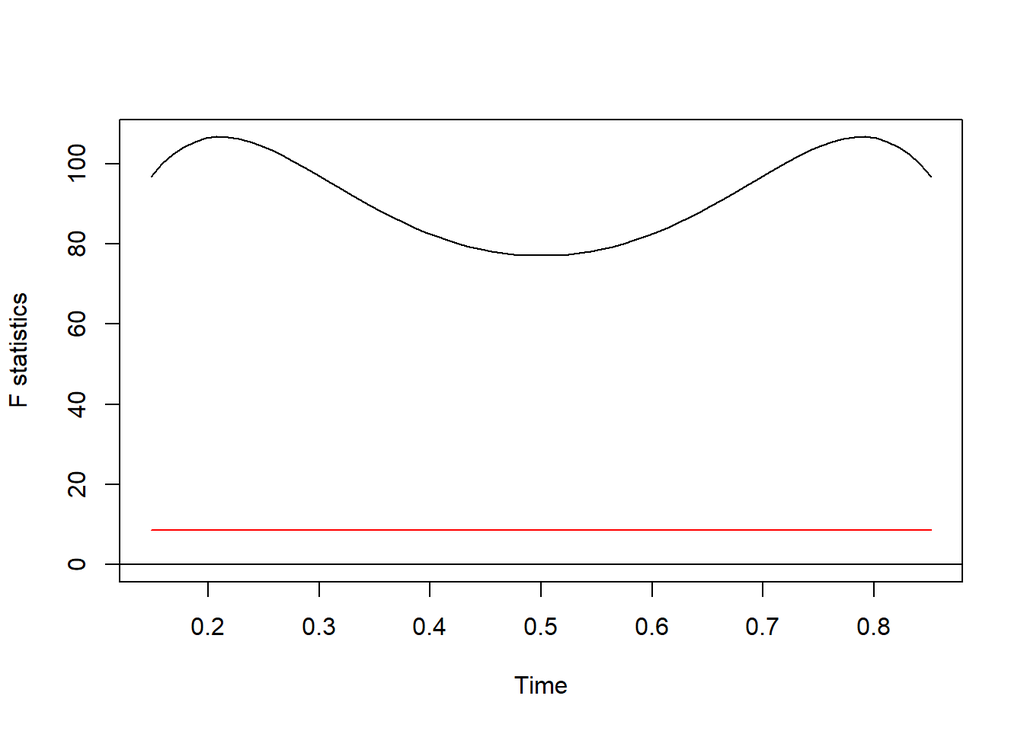

```r
f.break <- Fstats(y3~1)
plot(f.break)
```

```r
y3.bp<-breakpoints(y3~1,h=5)
y3.bp
```

```
##
##   Optimal 13-segment partition:
##
## Call:
## breakpoints.formula(formula = y3 ~ 1, h = 5)
##
## Breakpoints at observation number:
## 5 10 15 20 26 34 67 75 81 86 91 96
##
## Corresponding to breakdates:
## 0.04950495 0.0990099 0.1485149 0.1980198 0.2574257 0.3366337 0.6633663 0.7425743 0.8019802 0.8514851 0.9009901 0.950495
```

```r
plot(y3)
abline(v=time(y3)[y3.bp$breakpoints],col=2,lty=2)
```

[figure not shown]

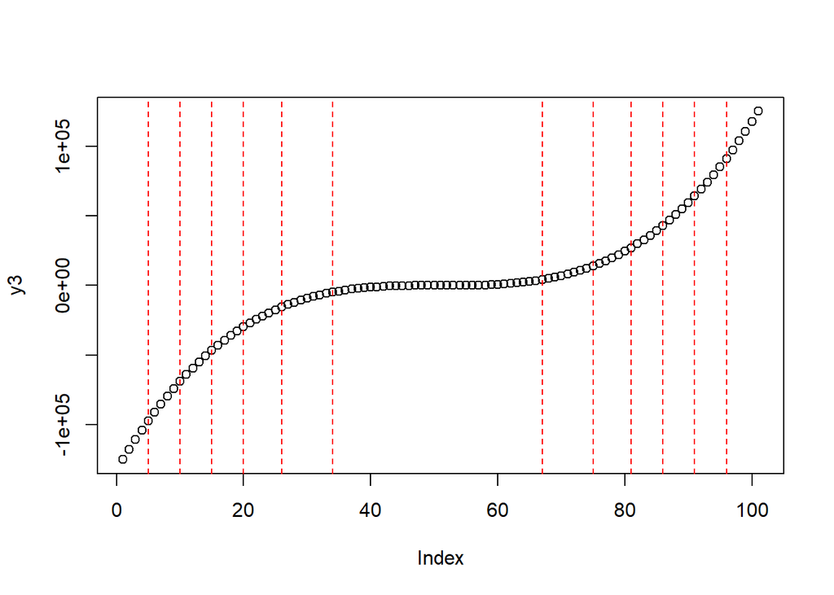

These graphs confirm our expectations!

# Closing Remarks

This was a rather long introduction to structural breaks, but hopefully does well to showcase some of the circumstances the procedure may be used. Next Friday, I’ll demonstrate how to use structural breaks with some real SAT data.

Anthony